[figure not shown]

# **NHÓM 7 DỮ LIỆU VỀ TIỂU ĐƯỜNG**

# **Thăm dò tập dữ liệu Pima Indian Diabetes**

#### *date: 2023-12-13*

## Installing module

```r
#install.packages('reader')
#install.packages("lattice")
#install.packages("reshape2")
#install.packages('ggplot2')
```

## Exploring data

```r
library(reader)
# Đọc file CSV trực tiếp từ đường link
diabetes <- read.csv("https://drive.google.com/uc?id=15mjrv0LV2T6GWNdAuW-QhXVdtMkQALlh")
# Hiển thị dữ liệu
head(diabetes)
```

```
##   Pregnancies Glucose BloodPressure SkinThickness Insulin  BMI
## 1           6     148            72            35       0 33.6
## 2           1      85            66            29       0 26.6
## 3           8     183            64             0       0 23.3
## 4           1      89            66            23      94 28.1
## 5           0     137            40            35     168 43.1
## 6           5     116            74             0       0 25.6
##   DiabetesPedigreeFunction Age Outcome
## 1                    0.627  50       1
## 2                    0.351  31       0
## 3                    0.672  32       1
## 4                    0.167  21       0
## 5                    2.288  33       1
## 6                    0.201  30       0
```

### Overall of dataset: dữ liệu y tế và nhân khẩu học của phụ nữ để dự đoán bệnh tiểu đường

- Mang thai: Số lần người phụ nữ đã mang thai.
- Glucose: Nồng độ glucose trong huyết tương của người phụ nữ.
- Huyết áp: Đo huyết áp.
- Độ dày của da: Độ dày của nếp gấp da ở cơ tam đầu.
- Insulin: Nồng độ insulin trong máu.
- BMI (Chỉ số khối cơ thể): Thước đo lượng mỡ trong cơ thể dựa trên chiều cao và cân nặng.
- Chức năng phả hệ bệnh tiểu đường: Một chức năng cho thấy khả năng mắc bệnh tiểu đường dựa trên tiền sử gia đình.
- Tuổi: Tuổi của người phụ nữ.
- Kết quả: Biến mục tiêu cho biết người phụ nữ có mắc bệnh tiểu đường hay không (1 đối với bệnh nhân tiểu đường, 0 đối với người không mắc bệnh tiểu đường).

#### Structure of dataset

```r
str(diabetes)
```

```
## 'data.frame':    768 obs. of  9 variables:
##  $ Pregnancies             : int  6 1 8 1 0 5 3 10 2 8 ...
##  $ Glucose                 : int  148 85 183 89 137 116 78 115 197 125 ...
##  $ BloodPressure           : int  72 66 64 66 40 74 50 0 70 96 ...
##  $ SkinThickness           : int  35 29 0 23 35 0 32 0 45 0 ...
##  $ Insulin                 : int  0 0 0 94 168 0 88 0 543 0 ...
##  $ BMI                     : num  33.6 26.6 23.3 28.1 43.1 25.6 31 35.3 30.5 0 ...
##  $ DiabetesPedigreeFunction: num  0.627 0.351 0.672 0.167 2.288 ...
##  $ Age                     : int  50 31 32 21 33 30 26 29 53 54 ...
##  $ Outcome                 : int  1 0 1 0 1 0 1 0 1 1 ...
```

Ta có thể thấy:

- Chỉ có 2 thuộc tính BMI và DiabetesPedigreeFunction là kiểu số thực, còn lại là int
- Tổng có 768 dòng và 9 cột

#### Summary of statistic

```r
summary(diabetes)
```

```
##   Pregnancies        Glucose      BloodPressure    SkinThickness
##  Min.   : 0.000   Min.   :  0.0   Min.   :  0.00   Min.   : 0.00
##  1st Qu.: 1.000   1st Qu.: 99.0   1st Qu.: 62.00   1st Qu.: 0.00
##  Median : 3.000   Median :117.0   Median : 72.00   Median :23.00
##  Mean   : 3.845   Mean   :120.9   Mean   : 69.11   Mean   :20.54
##  3rd Qu.: 6.000   3rd Qu.:140.2   3rd Qu.: 80.00   3rd Qu.:32.00
##  Max.   :17.000   Max.   :199.0   Max.   :122.00   Max.   :99.00
##     Insulin           BMI        DiabetesPedigreeFunction      Age
##  Min.   :  0.0   Min.   : 0.00   Min.   :0.0780           Min.   :21.00
##  1st Qu.:  0.0   1st Qu.:27.30   1st Qu.:0.2437           1st Qu.:24.00
##  Median : 30.5   Median :32.00   Median :0.3725           Median :29.00
##  Mean   : 79.8   Mean   :31.99   Mean   :0.4719           Mean   :33.24
##  3rd Qu.:127.2   3rd Qu.:36.60   3rd Qu.:0.6262           3rd Qu.:41.00
##  Max.   :846.0   Max.   :67.10   Max.   :2.4200           Max.   :81.00
##     Outcome
##  Min.   :0.000
##  1st Qu.:0.000
##  Median :0.000
##  Mean   :0.349
##  3rd Qu.:1.000
##  Max.   :1.000
```

#### Data visualization of distribution attributes

##### Distribution of Age, Pregnancies, Glucose and Outcome

```r
#install.packages("cowplot")
#install.packages("gridExtra")
library(ggplot2)
library(cowplot)
library(gridExtra)
```

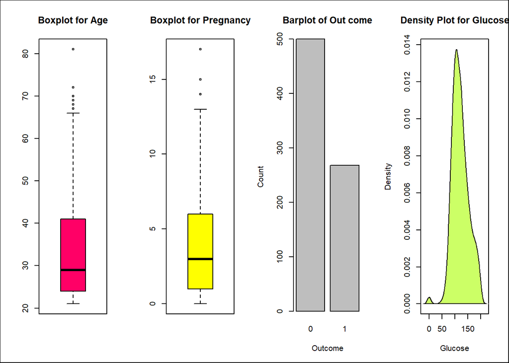

```r
par(mfrow=c(1,4))
# Boxplot cho Age
boxplot(diabetes$Age,
        col="#ff0066",
        main="Boxplot for Age")

# Boxplot cho Pregnancies
boxplot(diabetes$Pregnancies,
        col="yellow",
        main="Boxplot for Pregnancy")

# Boxplot cho Pregnancies
barplot(table(diabetes$Outcome), main = "Barplot of Out come", xlab = "Outcome", ylab="Count")

plot(density(diabetes$Glucose),
     col="yellow",
     main="Density Plot for Glucose",
     xlab="Glucose",
     ylab="Density")
polygon(density(diabetes$Glucose),
        col="#ccff66")

box(which = "outer", lty = "solid")
```

Ta có thể thấy:

##### The correlation of Glucose, Outcome and Insulin

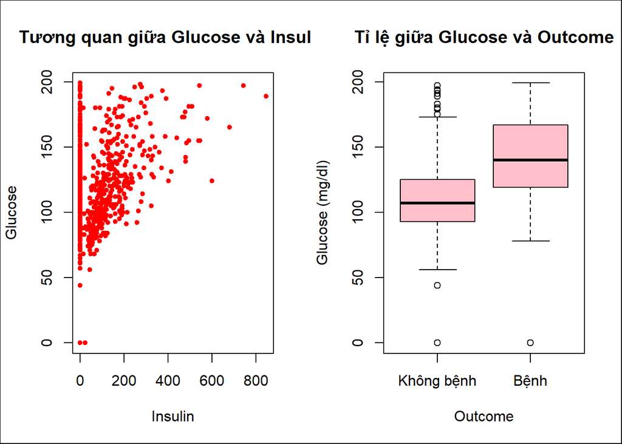

```r
par(mfrow=c(1,2))
plot(diabetes$Insulin, diabetes$Glucose, xlab="Insulin", ylab="Glucose", type='p', col=c("red"), pch=20, main="Tương quan giữa Glucose và Insulin")

# Boxplot cho Outcome và Glucose theo người mắc bệnh và không
diabetes_groups <- cut(diabetes$Outcome, c(-Inf, 0, Inf), labels = c("Không bệnh", "Bệnh"))
boxplot(diabetes$Glucose~diabetes_groups, xlab="Outcome", ylab="Glucose (mg/dl)", main="Tỉ lệ giữa Glucose và Outcome", col="pink")

box(which="outer", lty="solid")
```

#### The correlation between attributes and Outcome

*Cách tính đường hồi quy tuyến tính:*

- Tính tổng các bình phương khoảng cách d tới đường hồi quy sao cho là bé nhất với mọi điểm dữ liệu. Ta sẽ được đường hồi quy phù hợp nhất

$$sum_{min} = d_1^2+d_2^2+d_3^2+... \\$$

- Công thức tính khoảng cách từ 1 điểm đến 1 đường thẳng

$$d(M, \Delta) = \sqrt{\dfrac{|ax_0+by_0+c|}{a^2+b^2}} \\$$

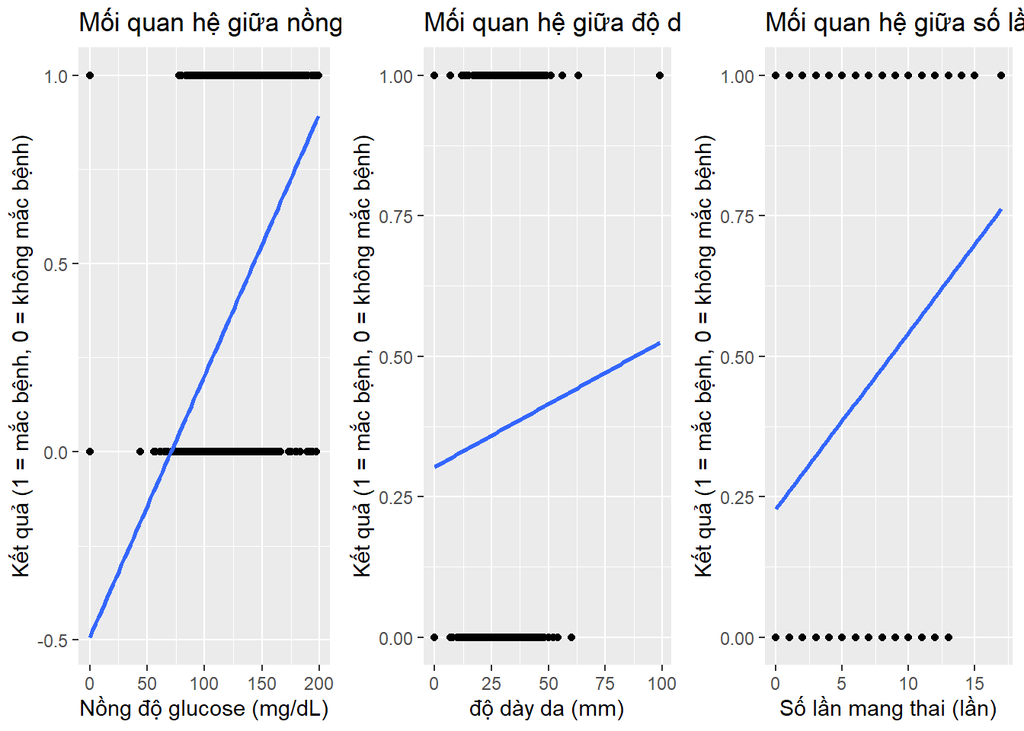

```r
p1 <- ggplot(data = diabetes, aes(x = Glucose, y = Outcome)) +
  geom_point() +
  geom_smooth(method = "lm", se = FALSE) +
  labs(title = "Mối quan hệ giữa nồng độ glucose và kết quả bệnh tiểu đường",
       x = "Nồng độ glucose (mg/dL)",
       y = "Kết quả (1 = mắc bệnh, 0 = không mắc bệnh)")

p2 <- ggplot(data = diabetes, aes(x = SkinThickness, y = Outcome)) +
  geom_point() +
  geom_smooth(method = "lm", se = FALSE) +
  labs(title = "Mối quan hệ giữa độ dày của da và kết quả bệnh tiểu đường",
       x = "độ dày da (mm)",
       y = "Kết quả (1 = mắc bệnh, 0 = không mắc bệnh)")

p3 <- ggplot(data = diabetes, aes(x = Pregnancies, y = Outcome)) +
  geom_point() +
  geom_smooth(method = "lm", se = FALSE) +
  labs(title = "Mối quan hệ giữa số lần mang thai và kết quả bệnh tiểu đường",
       x = "Số lần mang thai (lần)",
       y = "Kết quả (1 = mắc bệnh, 0 = không mắc bệnh)")

grid.arrange(p1, p2, p3, ncol = 3)
```

Ta có thể thấy

- Theo đường hồi quy tuyến tính dương trên, số lần mang thai hoặc nồng độ glucose càng tăng thì tỉ lệ mắc bệnh tiểu đường càng cao
- Ngược lại, độ dày của da không ảnh hưởng quá mạnh vào khả năng mắc bệnh tiểu đường

#### Kiểm tra giá trị rỗng

```r
sum_of_nan <- sum(is.na(diabetes))
paste("Tổng số giá trị rỗng trong dataset:", sum_of_nan)
```

```
## [1] "Tổng số giá trị rỗng trong dataset: 0"
```

```r
for (col in colnames(diabetes)) {
  nan_of_col <- sum(is.na(diabetes[, col]))
  print(paste("Số giá trị rỗng trong cột", col, ":", nan_of_col))
}
```

```
## [1] "Số giá trị rỗng trong cột Pregnancies : 0"
## [1] "Số giá trị rỗng trong cột Glucose : 0"
## [1] "Số giá trị rỗng trong cột BloodPressure : 0"
## [1] "Số giá trị rỗng trong cột SkinThickness : 0"
## [1] "Số giá trị rỗng trong cột Insulin : 0"
## [1] "Số giá trị rỗng trong cột BMI : 0"
## [1] "Số giá trị rỗng trong cột DiabetesPedigreeFunction : 0"
## [1] "Số giá trị rỗng trong cột Age : 0"
## [1] "Số giá trị rỗng trong cột Outcome : 0"
```

#### Kiểm tra giá trị ngoại lai

##### Tìm giá trị ngoại lai

```r
find_outliers <- function(inp, na.rm = TRUE) {
  i.qnt <- quantile(inp, probs = c(0.25, 0.75), na.rm = na.rm)
  i.max <- 1.5 * IQR(inp, na.rm = na.rm)

  outliers <- inp < (i.qnt[1] - i.max) | inp > (i.qnt[2] + i.max)

  return(outliers)
}
```

##### Lập tỉ lệ outliers trong cột tương ứng

```r
calculate_rate <- function(inp) {
  num_outliers <- sum(find_outliers(inp))
  num_regular <- length(inp) - num_outliers

  outlier_rate <- num_outliers / length(inp) * 100
  regular_rate <- num_regular / length(inp) * 100

  rates <- list(outlier=outlier_rate, regular=regular_rate)
  return (rates)
}
```

```r
for (col in colnames(diabetes)) {
  rates <- calculate_rate(unlist(diabetes[, col]))
  # Liệt kê tỉ lệ giá trị ngoại lại trong từng cột
  print(paste(col, "-", "Total Outliers (%):", round(rates$outlier, 2), ", Regular Values (%):", round(rates$outlier, 2)))
}
```

```
## [1] "Pregnancies - Total Outliers (%): 0.52 , Regular Values (%): 0.52"
## [1] "Glucose - Total Outliers (%): 0.65 , Regular Values (%): 0.65"
## [1] "BloodPressure - Total Outliers (%): 5.86 , Regular Values (%): 5.86"
## [1] "SkinThickness - Total Outliers (%): 0.13 , Regular Values (%): 0.13"
## [1] "Insulin - Total Outliers (%): 4.43 , Regular Values (%): 4.43"
## [1] "BMI - Total Outliers (%): 2.47 , Regular Values (%): 2.47"
## [1] "DiabetesPedigreeFunction - Total Outliers (%): 3.78 , Regular Values (%): 3.78"
## [1] "Age - Total Outliers (%): 1.17 , Regular Values (%): 1.17"
## [1] "Outcome - Total Outliers (%): 0 , Regular Values (%): 0"
```

##### Vẽ trực quan tỉ lệ ngoại lai

```r
pie_outlier <- function(outlier_col) {for (col in outlier_col) {
  rates <- calculate_rate(unlist(diabetes[, col]))

  pie_data <- data.frame(
    type = c("Outliers", "Regular"),
    rate = c(rates$outlier, rates$regular)
  )

  # Vẽ trực quan những cột có tỉ lệ ngoại lai >= 2.3%
  return(ggplot(pie_data, aes(x="", y = rate, fill=type)) +
  geom_bar(stat="identity", width=1, color="white") +
  coord_polar("y", start=0) +
  theme_void() +
  labs(title = paste(col),
     caption = paste0("Total Outliers (%):", round(rates$outlier, 2), ", Regular Values (%):", round(rates$regular, 2))))
}}
```

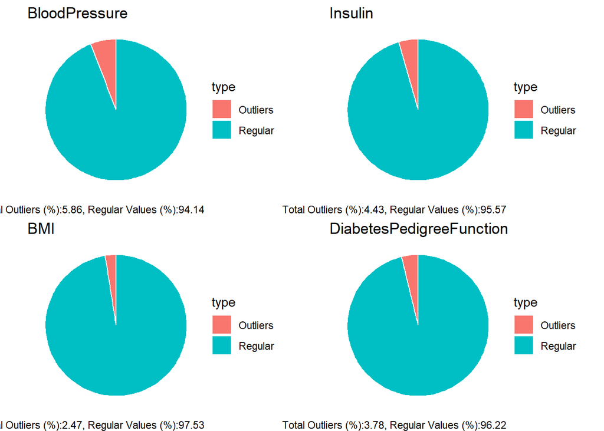

```r
grid.arrange(pie_outlier("BloodPressure"), pie_outlier("Insulin"), pie_outlier("BMI"), pie_outlier("DiabetesPedigreeFunction"), ncol=2)
```

#### Kiểm tra độ tương quan của các thuộc tính

```r
library(lattice)
library(reshape2)
```

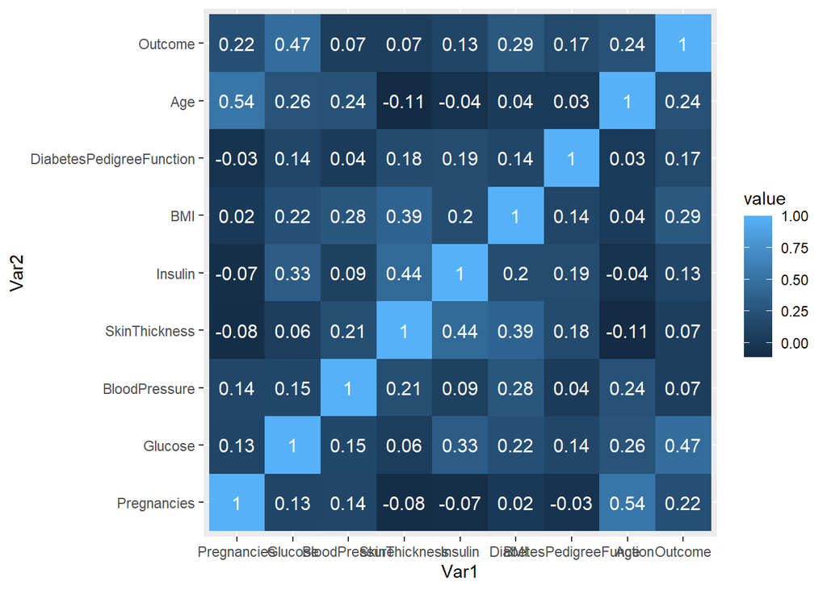

```r
# creating correlation matrix
corr_mat <- round(cor(diabetes),2)

# reduce the size of correlation matrix
melted_corr_mat <- melt(corr_mat)
# head(melted_corr_mat)

# plotting the correlation heatmap
library(ggplot2)
ggplot(data = melted_corr_mat, aes(x=Var1, y=Var2, fill=value)) + geom_tile() +
  geom_text(aes(Var2, Var1, label = value), color = "white", size = 4)
```

## II.Tiền xử lí dữ liệu

### **Chuẩn bị các thư viện**

```r
#install.packages("readr")
#install.packages("dplyr")
#install.packages("tidyr")
#install.packages("ggplot2")
```

```r
library(readr)
library(dplyr)
library(tidyr)
```

```r
library(ggplot2)
```

### Xử lí giá trị bị thiếu

#### Kiểm tra các giá trị bị thiếu

*Kiểm tra các giá trị bị thiếu của từng cột*

```r
na_count<-colSums(sapply(diabetes,is.na))
na_count
```

```
##              Pregnancies                  Glucose            BloodPressure
##                        0                        0                        0
##            SkinThickness                  Insulin                      BMI
##                        0                        0                        0
## DiabetesPedigreeFunction                      Age                  Outcome
##                        0                        0                        0
```

*Bộ dữ liệu này không tồn tại giá trị bị thiếu*

#### Các phương pháp xử lí giá trị bị thiếu

*Giới thiệu 3 phương pháp xử lí giá trị bị thiếu :*

*Điền giá trị trung vị.*

```r
diabetes_median <- diabetes %>%
mutate_all(~ ifelse(is.na(.), median(., na.rm = TRUE), .))
```

*Điền giá trị trung bình.*

```r
diabetes_mean <- diabetes %>%
mutate_all(~ ifelse(is.na(.), mean(., na.rm = TRUE), .))
```

*Điền giá trị phổ biến nhất.*

```r
fill_mode <- function(x) {
  mode_val <- names(sort(table(x), decreasing = TRUE))[1]
  x[is.na(x)] <- mode_val
  return(x)
}

diabetes_mode <- diabetes %>%
mutate_all(fill_mode)
```

### Xử lí giá trị ngoại lai

#### Phương pháp xử lý giá trị ngoại lai dựa trên ma trận Z-score

*Bước 1:Tìm Z-score cho tất cả các điểm trong tập dữ liệu*

*Bước 2: Vẽ biểu đồ Scatter Plots biểu diễn ma trận Z-score*

*Bước 3: Quan sát biểu đồ Z-score,tìm Z-score ngưỡng*

*Bước 4: Dựa trên Z-score ngưỡng và loại các giá trị vượt qua Z-score ngưỡng đó*

#### *Ta có công thức như sau :*

$$Z = \frac{{X - \bar{X}}}{{\sigma}}$$

*Trong đó:*

- $X$ là giá trị của một điểm dữ liệu cụ thể trong một thuộc tính nào đó.
- $\bar{X}$ là giá trị trung bình của thuộc tính đó trong tập dữ liệu.
- $\sigma$ là độ lệch chuẩn của thuộc tính đó trong tập dữ liệu.

*Áp dụng công thức trên để biến đổi bộ dữ liệu thành ma trận Z-score*

```r
diabetes_z <- (diabetes - colMeans(diabetes)) / apply(diabetes, 2, sd)
head(diabetes_z)
```

```
##   Pregnancies      Glucose BloodPressure SkinThickness     Insulin       BMI
## 1   0.6395305   7.99033370   215.8827363     9.2459493  -1.2873733 99.985707
## 2  -3.7499128   0.04512617     2.7855842    -2.8741635  -0.6924393 -0.564690
## 3  -3.1569579  19.15326626   133.4539425    -3.5702706  -4.0578295 48.120296
## 4  -1.2246861 267.19131711    18.4459142     0.1544326 282.2820762  7.198215
## 5  -0.6924393   8.82288025    -2.5301191    -0.3887359  11.4588828 -2.433161
## 6  -3.4236465 242.47973103     0.2528715    -4.0578295  -0.7316434 -2.247670
##   DiabetesPedigreeFunction           Age   Outcome
## 1               -0.9550312  1.8469872005  1.593957
## 2               -3.7702115 -0.4234448489 -2.826550
## 3               -3.5355523  0.0009413653  1.365006
## 4               -1.2769045 61.9569937727 -1.141108
## 5               -0.6725858 -0.0204830505 -3.749913
## 6               -4.0323353 62.1678499768 -3.570271
```

#### Vẽ biểu đồ Scatter Plots biểu diễn ma trận Z-score

*Biểu đồ này cho phép chúng ta quan sát được các giá trị ngoại lai*

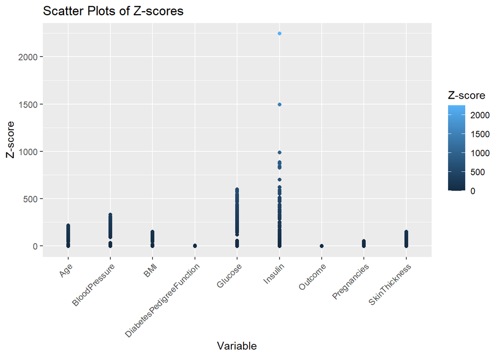

```r
melted_diabetes <- gather(diabetes_z, key = "Variable", value = "Z-score")

# Vẽ scatter plot cho tất cả các cột
ggplot(melted_diabetes, aes(x = Variable, y = `Z-score`, color = `Z-score`)) +
  geom_point() +
  labs(x = "Variable", y = "Z-score", title = "Scatter Plots of Z-scores") +
  theme(axis.text.x = element_text(angle = 45, hjust = 1))  # Điều chỉnh góc và vị trí của chú thích trên trục x
```

#### Quan sát biểu đồ ta thấy được các điểm Z-score >=700 là các giá trị ngoại lai

*Ta chọn Z-score ngưỡng là 700 và loại các giá trị Z-score mà vượt qua ngưỡng đó*

```r
# Lọc các giá trị Z-score mà tất cả đều nhỏ hơn 700
diabetes_filter <- diabetes[rowSums(apply(diabetes_z, 2, function(x) abs(x) < 700)) == ncol(diabetes_z), ]

# Hiển thị kích thước của bộ dữ liệu sau khi loại bỏ
cat("Còn lại số lượng hàng và cột là:", dim(diabetes_filter))
```

```
## Còn lại số lượng hàng và cột là: 760 9
```

### Loại bỏ các cột không cần thiết (nếu có) cho việc xây dựng mô hình

#### Vẽ biểu đồ hộp để xem sự phân phối dữ liệu của biến mục tiêu và biến độc lập

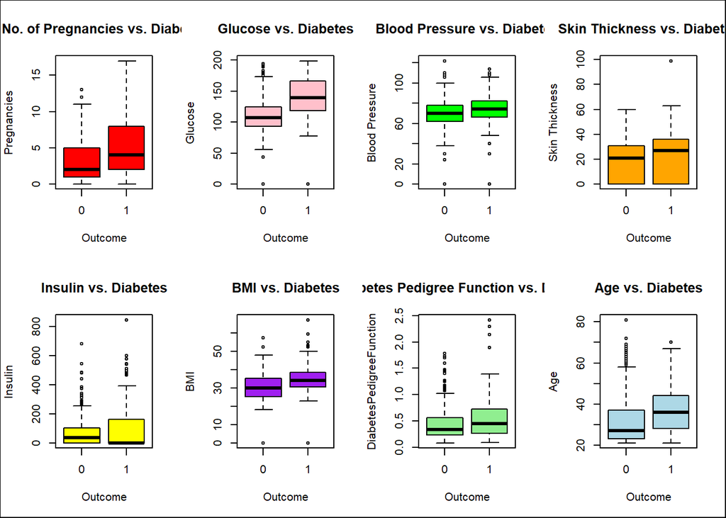

```r
attach(diabetes_filter)
par(mfrow=c(2,4))
boxplot(Pregnancies~Outcome, main="No. of Pregnancies vs. Diabetes",
        xlab="Outcome", ylab="Pregnancies",col="red")
boxplot(Glucose~Outcome, main="Glucose vs. Diabetes",
        xlab="Outcome", ylab="Glucose",col="pink")
boxplot(BloodPressure~Outcome, main="Blood Pressure vs. Diabetes",
        xlab="Outcome", ylab="Blood Pressure",col="green")
boxplot(SkinThickness~Outcome, main="Skin Thickness vs. Diabetes",
        xlab="Outcome", ylab="Skin Thickness",col="orange")
boxplot(Insulin~Outcome, main="Insulin vs. Diabetes",
        xlab="Outcome", ylab="Insulin",col="yellow")
boxplot(BMI~Outcome, main="BMI vs. Diabetes",
        xlab="Outcome", ylab="BMI",col="purple")
boxplot(DiabetesPedigreeFunction~Outcome, main="Diabetes Pedigree Function vs. Diabetes", xlab="Outcome", ylab="DiabetesPedigreeFunction",col="lightgreen")
boxplot(Age~Outcome, main="Age vs. Diabetes",
        xlab="Outcome", ylab="Age",col="lightblue")
box(which = "outer", lty = "solid")
```

```r
diabetes_f<-diabetes_filter
```

#### Huyết áp và độ dày của da ít thay đổi với bệnh tiểu đường, chúng sẽ bị loại khỏi mô hình. Các biến khác ít nhiều cho thấy mối tương quan với bệnh tiểu đường nên sẽ được giữ nguyên

```r
diabetes_f $BloodPressure <- NULL
diabetes_f $SkinThickness <- NULL

dim(diabetes_f)
```

```
## [1] 760   7
```

### Chuẩn hoá dữ liệu

#### Phương pháp chuẩn hoá dữ liệu bằng MinMax-Scaler

#### Mục đích

- *Đảm bảo rằng các biến có thang đo đồng nhất.*
- *Miền giá trị nằm trong Khoảng (0-1).*
- *Giúp mô hình học tốt hơn.*
- *Giảm ảnh hưởng của biên độ lớn giữa các biến.*

#### Công thức :

$$\text{Scaled Value} = \frac{{X -
\text{min}(X)}}{{\text{max}(X) - \text{min}(X)}}$$

```r
min_max_scaler <- function(x) {
  return ((x - min(x)) / (max(x) - min(x)))
}

diabetes_scale <- as.data.frame(lapply(diabetes_f, min_max_scaler))
head(diabetes_scale)
```

```
##   Pregnancies   Glucose   Insulin       BMI DiabetesPedigreeFunction       Age
## 1  0.35294118 0.7437186 0.0000000 0.5007452               0.23441503 0.4833333
## 2  0.05882353 0.4271357 0.0000000 0.3964232               0.11656704 0.1666667
## 3  0.47058824 0.9195980 0.0000000 0.3472429               0.25362938 0.1833333
## 4  0.05882353 0.4472362 0.1111111 0.4187779               0.03800171 0.0000000
## 5  0.00000000 0.6884422 0.1985816 0.6423249               0.94363792 0.2000000
## 6  0.29411765 0.5829146 0.0000000 0.3815201               0.05251921 0.1500000
##   Outcome
## 1       1
## 2       0
## 3       1
## 4       0
## 5       1
## 6       0
```